# Homework 6

Alison Hall

2/19/2020

Load the pertinent libraries

```r
library(ggplot2) # for graphics
library(MASS) # for maximum likelihood estimation
```

Input my data

```r
z <- read.table("UrchinSalinityAssay.csv",header=TRUE,sep=",", stringsAsFactors=FALSE)
str(z)
```

```
## 'data.frame':    7 obs. of  16 variables:
##  $ ï..Urchin: int  1 2 3 4 6 7 8
##  $ State    : chr  "Gradual" "Gradual" "Steady" "Steady" ...
##  $ Day1     : int  167 115 136 114 144 109 62
##  $ Day2     : int  120 150 82 163 141 63 108
##  $ Day3     : int  92 102 114 495 145 126 68
##  $ Day4     : int  103 210 393 612 177 164 103
##  $ Day5     : int  74 158 334 273 287 121 81
##  $ Day6     : int  480 158 688 228 134 165 80
##  $ Day7     : int  122 136 279 286 177 191 146
##  $ Day8     : int  438 139 307 246 281 365 124
##  $ Day9     : int  259 244 120 286 101 365 124
##  $ Day10    : int  182 129 69 124 230 62 126
##  $ Day11    : int  183 190 92 236 333 97 190
##  $ Day12    : int  328 180 84 206 261 79 215
##  $ Day13    : int  362 345 74 123 179 83 192
##  $ Day14    : int  452 251 83 312 233 109 159
```

```r
summary(z)
```

```
##    ï..Urchin        State                Day1            Day2
##  Min.   :1.000   Length:7           Min.   : 62.0   Min.   : 63.0
##  1st Qu.:2.500   Class :character   1st Qu.:111.5   1st Qu.: 95.0
##  Median :4.000   Mode  :character   Median :115.0   Median :120.0
##  Mean   :4.429                      Mean   :121.0   Mean   :118.1
##  3rd Qu.:6.500                      3rd Qu.:140.0   3rd Qu.:145.5
##  Max.   :8.000                      Max.   :167.0   Max.   :163.0
##       Day3            Day4            Day5            Day6
##  Min.   : 68.0   Min.   :103.0   Min.   : 74.0   Min.   : 80.0
##  1st Qu.: 97.0   1st Qu.:133.5   1st Qu.:101.0   1st Qu.:146.0
##  Median :114.0   Median :177.0   Median :158.0   Median :165.0
##  Mean   :163.1   Mean   :251.7   Mean   :189.7   Mean   :276.1
##  3rd Qu.:135.5   3rd Qu.:301.5   3rd Qu.:280.0   3rd Qu.:354.0
##  Max.   :495.0   Max.   :612.0   Max.   :334.0   Max.   :688.0
##       Day7          Day8            Day9           Day10
##  Min.   :122   Min.   :124.0   Min.   :101.0   Min.   : 62.0
##  1st Qu.:141   1st Qu.:192.5   1st Qu.:122.0   1st Qu.: 96.5
##  Median :177   Median :281.0   Median :244.0   Median :126.0
##  Mean   :191   Mean   :271.4   Mean   :214.1   Mean   :131.7
##  3rd Qu.:235   3rd Qu.:336.0   3rd Qu.:272.5   3rd Qu.:155.5
##  Max.   :286   Max.   :438.0   Max.   :365.0   Max.   :230.0
##      Day11           Day12           Day13           Day14
##  Min.   : 92.0   Min.   : 79.0   Min.   : 74.0   Min.   : 83.0
##  1st Qu.:140.0   1st Qu.:132.0   1st Qu.:103.0   1st Qu.:134.0
##  Median :190.0   Median :206.0   Median :179.0   Median :233.0
##  Mean   :188.7   Mean   :193.3   Mean   :194.0   Mean   :228.4
##  3rd Qu.:213.0   3rd Qu.:238.0   3rd Qu.:268.5   3rd Qu.:281.5
##  Max.   :333.0   Max.   :328.0   Max.   :362.0   Max.   :452.0
```

```r
library(tidyr)
long_urchins <- gather(z, Day, Flip_Time, Day1:Day14)
print(long_urchins)
```

```
##    ï..Urchin   State   Day Flip_Time
## 1          1 Gradual  Day1       167
## 2          2 Gradual  Day1       115
## 3          3  Steady  Day1       136
## 4          4  Steady  Day1       114
## 5          6 Gradual  Day1       144
## 6          7  Steady  Day1       109
## 7          8  Steady  Day1        62
## 8          1 Gradual  Day2       120
## 9          2 Gradual  Day2       150
## 10         3  Steady  Day2        82
## 11         4  Steady  Day2       163
## 12         6 Gradual  Day2       141
## 13         7  Steady  Day2        63
## 14         8  Steady  Day2       108
```

[output cut: 84 more lines]

Generate fake data

```r
#z <- rnorm(n=3000,mean=0.2)
#z <- data.frame(1:3000,z)
#names(z) <- list("ID","myVar")
#z <- z[z$myVar>0,]
#str(z)
#summary(z$myVar)
```

Make histograms of density of time (seconds) it took a sea urchin to “right” itself after being flipped over

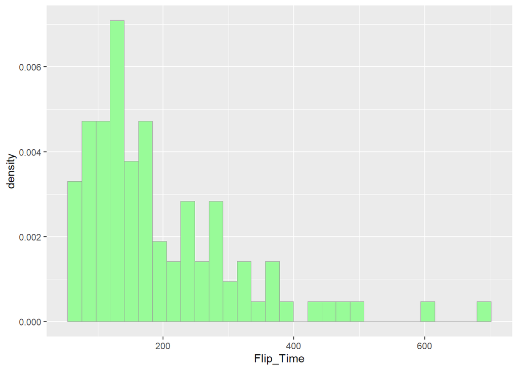

```r
p1 <- ggplot(data=long_urchins, aes(x=Flip_Time, y=..density..)) +
  geom_histogram(color="grey60",fill="palegreen",size=0.2)
print(p1)
```

Add an emperical curve. This dotted line fits the data to smooth out the shape of the histogram

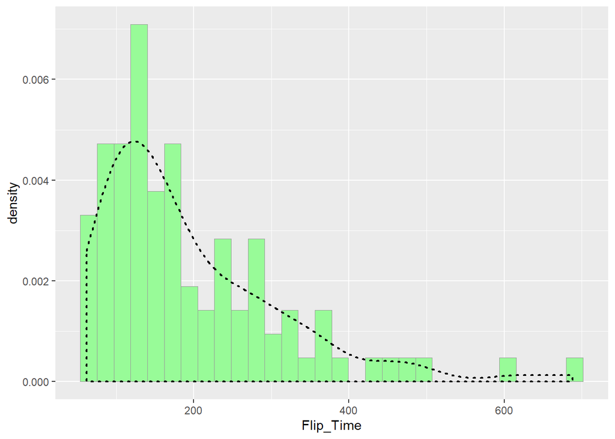

```r
p1 <-  p1 +  geom_density(linetype="dotted",size=0.75)
print(p1)
```

```r
normPars <- fitdistr(long_urchins$Flip_Time,"normal")
print(normPars)
```

```
##       mean          sd
##   195.183673   120.121482
##  ( 12.134102) (  8.580106)
```

```r
str(normPars)
```

```
## List of 5
##  $ estimate: Named num [1:2] 195 120
##   ..- attr(*, "names")= chr [1:2] "mean" "sd"
##  $ sd      : Named num [1:2] 12.13 8.58
##   ..- attr(*, "names")= chr [1:2] "mean" "sd"
##  $ vcov    : num [1:2, 1:2] 147.2 0 0 73.6
##   ..- attr(*, "dimnames")=List of 2
##   .. ..$ : chr [1:2] "mean" "sd"
##   .. ..$ : chr [1:2] "mean" "sd"
##  $ n       : int 98
##  $ loglik  : num -608
##  - attr(*, "class")= chr "fitdistr"
```

```r
normPars$estimate["mean"] # note structure of getting a named attribute
```

```
##     mean
## 195.1837
```

This added line represents the probability density for the normal distribution. This is the best fit line for the data if the data were normally distributed.

```r
meanML <- normPars$estimate["mean"]
sdML <- normPars$estimate["sd"]

xval <- seq(0,max(long_urchins$Flip_Time),len=length(long_urchins$Flip_Time))

stat <- stat_function(aes(x = Flip_Time, y = ..y..), fun = dnorm, colour="darkorchid", n = length(long_urchins$Flip_Time), args = list(mean = meanML, sd = sdML))
 p1 + stat
```

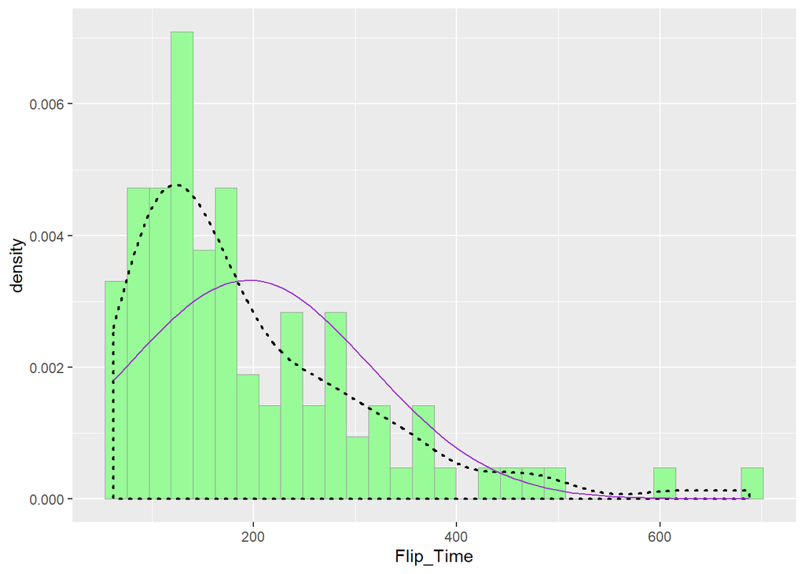

Here is the fit for exponential curve:

```r
expoPars <- fitdistr(long_urchins$Flip_Time,"exponential")
rateML <- expoPars$estimate["rate"]

stat2 <- stat_function(aes(x = xval, y = ..y..), fun = dexp, colour="blue", n = length(long_urchins$Flip_Time), args = list(rate=rateML))
 p1 + stat + stat2
```

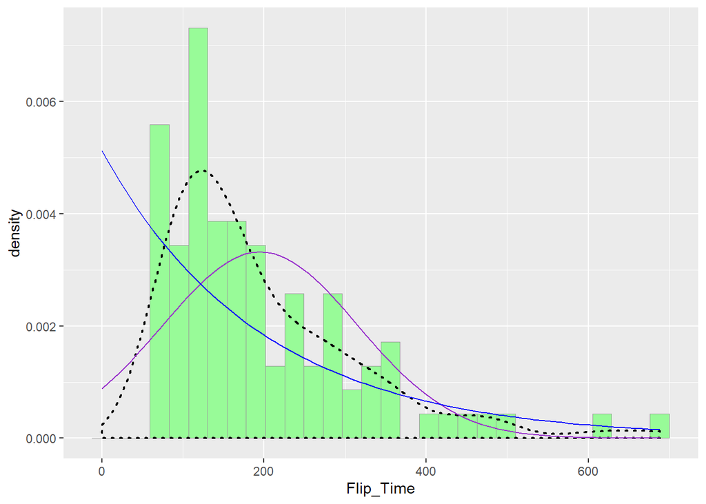

Find the maximum liklihood estimators, which are just the minimum and maximum of the flip times.

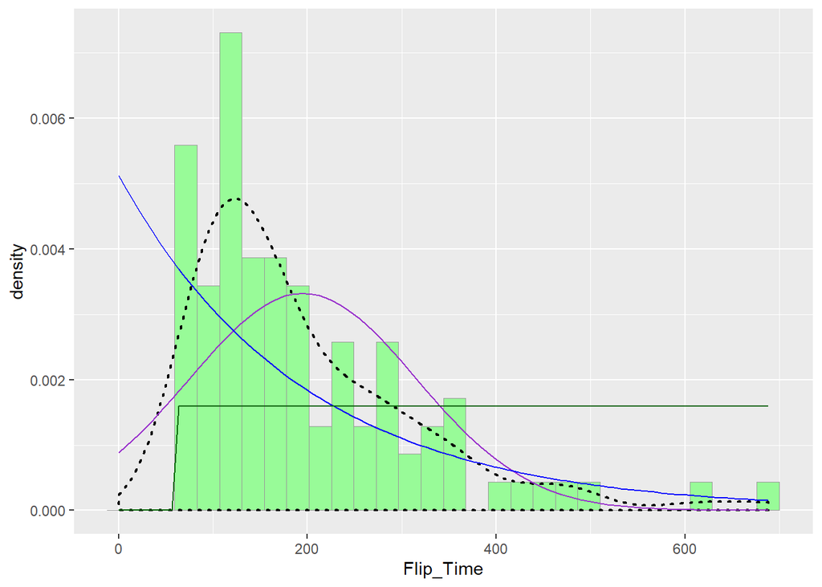

```r
stat3 <- stat_function(aes(x = xval, y = ..y..), fun = dunif, colour="darkgreen", n = length(long_urchins$Flip_Time), args = list(min=min(long_urchins$Flip_Time), max=max(long_urchins$Flip_Time)))
p1 + stat + stat2 + stat3
```

Plot of the gamma probability density:

```r
gammaPars <- fitdistr(long_urchins$Flip_Time,"gamma")
shapeML <- gammaPars$estimate["shape"] #these are my max liliehood params
rateML <- gammaPars$estimate["rate"]

stat4 <- stat_function(aes(x = xval, y = ..y..), fun = dgamma, colour="chocolate1", n = length(long_urchins$Flip_Time), args = list(shape=shapeML, rate=rateML))
 p1 + stat + stat2 + stat3 + stat4
```

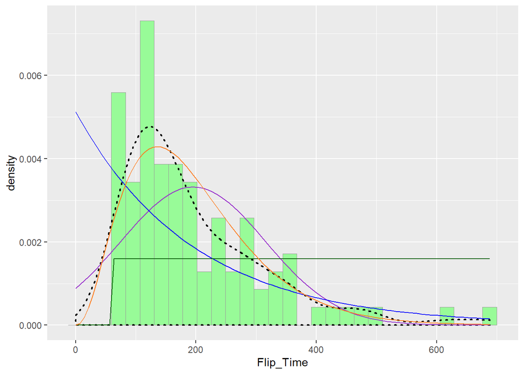

Plot beta probability density: raw data are rescaled to be between 0 and 1 and compared to the beta

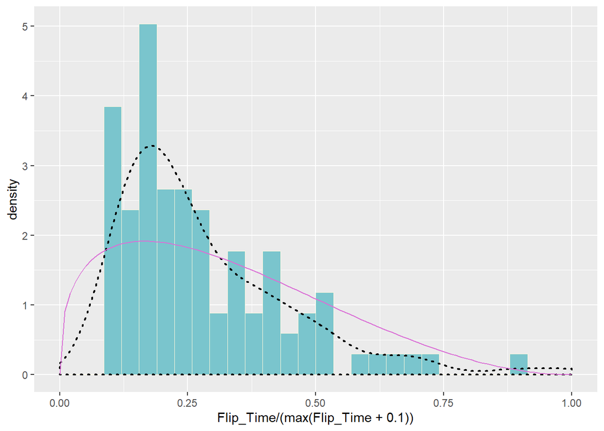

```r
pSpecial <- ggplot(data=long_urchins, aes(x= Flip_Time/(max(Flip_Time + 0.1)), y=..density..)) +
  geom_histogram(color="cornsilk",fill="cadetblue3",size=0.2) +
  xlim(c(0,1)) +
  geom_density(size=0.75,linetype="dotted")

betaPars <- fitdistr(x=long_urchins$Flip_Time/max(long_urchins$Flip_Time + 0.1),start=list(shape1=1,shape2=2),"beta")
shape1ML <- betaPars$estimate["shape1"]
shape2ML <- betaPars$estimate["shape2"]

statSpecial <- stat_function(aes(x = xval, y = ..y..), fun = dbeta, colour="orchid", n = length(long_urchins$Flip_Time), args = list(shape1=shape1ML,shape2=shape2ML))
pSpecial + statSpecial
```

Gamma distribution seems to fit best, so I made a gamma distributed data set using rgamma that is the same size as my data set.

```r
gamma <- rgamma(n=98,shapeML,rateML)
gamma <- data.frame(1:98,gamma)
names(gamma) <-list("GeneratedGamma","Variable")
str(gamma)
```

```
## 'data.frame':    98 obs. of  2 variables:
##  $ GeneratedGamma: int  1 2 3 4 5 6 7 8 9 10 ...
##  $ Variable      : num  229 145 235 364 110 ...
```

```r
summary(gamma$myVar)
```

```
## Length  Class   Mode
##      0   NULL   NULL
```

Here is a histogram of the density of these data.

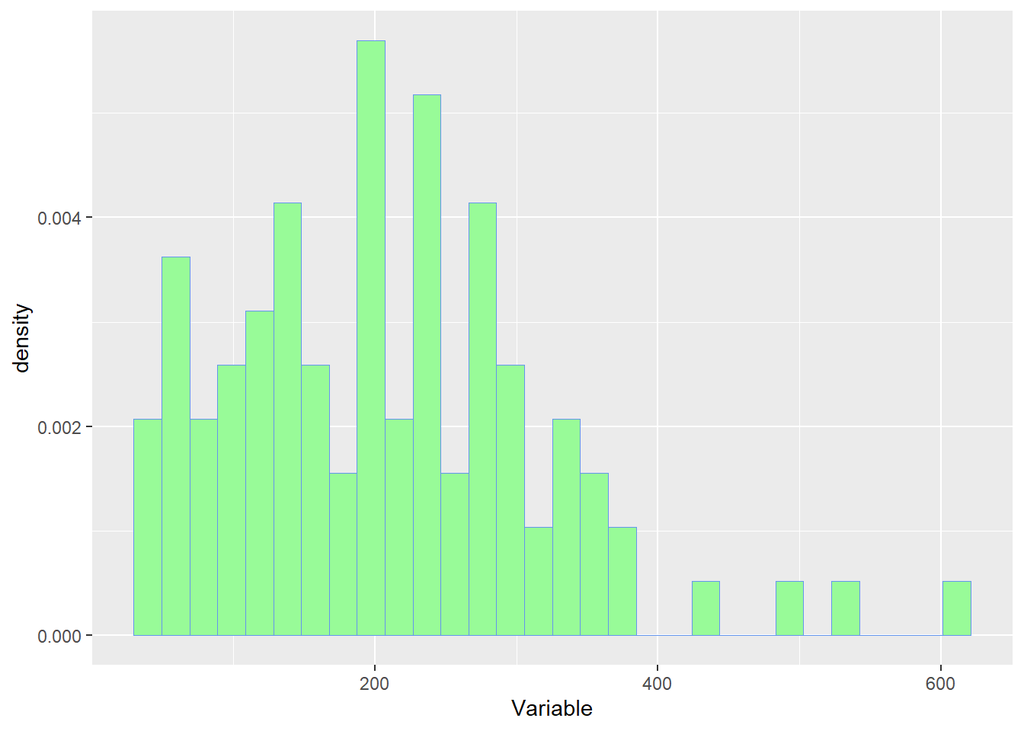

```r
generatedp1 <- ggplot(data=gamma, aes(x=Variable, y=..density..)) +
  geom_histogram(color="cornflowerblue",fill="palegreen",size=0.2)
print(generatedp1)
```

This adds a dotted line that is the probability density curve

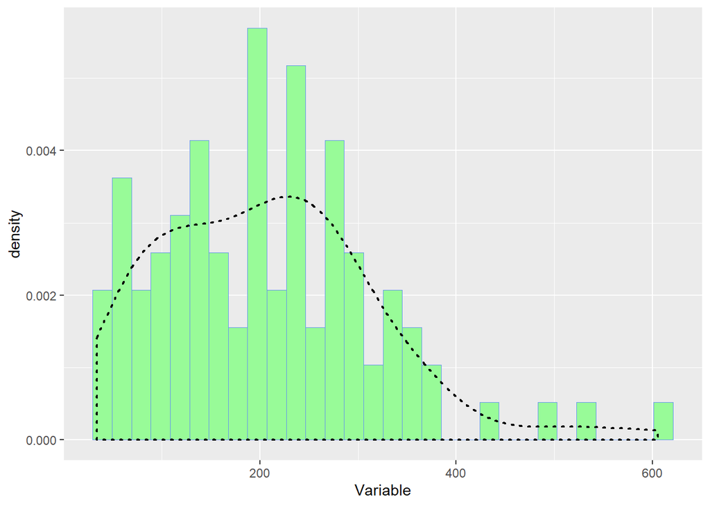

```r
generatedp1 <-  generatedp1 +  geom_density(linetype="dotted",size=0.75)
print(generatedp1)
```

For a refresher here is the actual data.

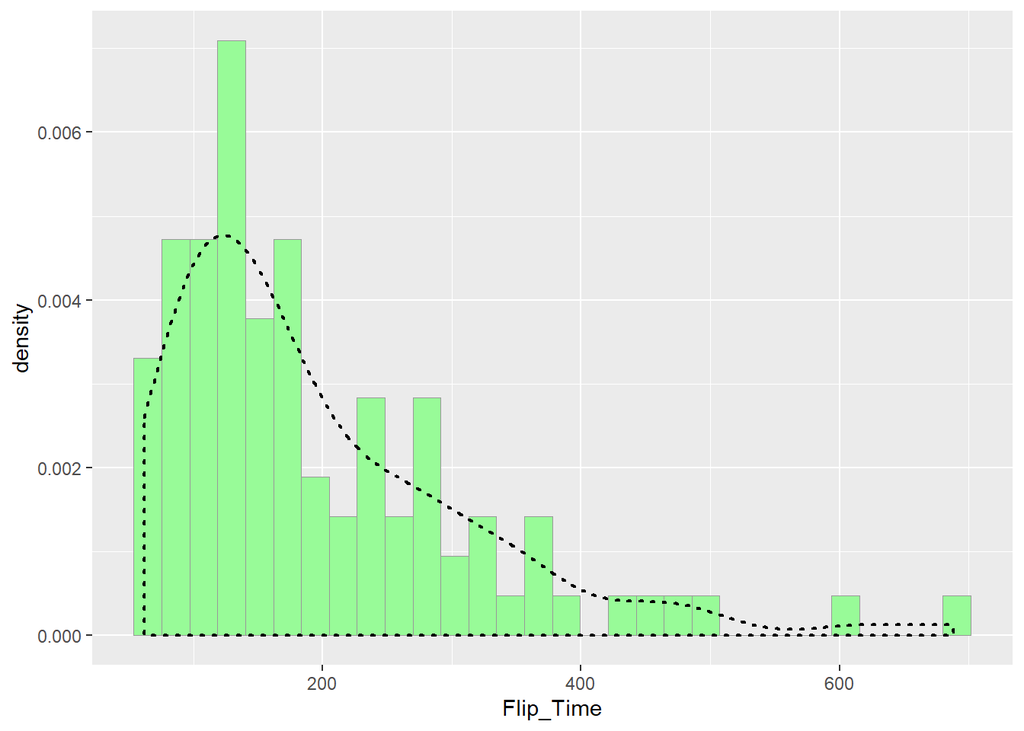

```r
p1 <- ggplot(data=long_urchins, aes(x=Flip_Time, y=..density..)) +
  geom_histogram(color="grey60",fill="palegreen",size=0.2)


p1 <-  p1 +  geom_density(linetype="dotted",size=0.75)
print(p1)
```